# (노트) ggplot2- Scale, Legend, Theme

Jan 10, 2022 • 신록예찬 • 2 min read

R

- imports
- 범례
  - 범례제거
  - 범례의 크기조정
  - 범례제목내용변경
  - 범례제목스타일변경
  - legend
    - 범례제거
    - 범례크기조정
    - 범례제목스타일변경
    - 범례제목삭제
    - 범례에속한라벨변경
  - axis
    - 축 눈금제거
  - subplot layout
    - grid.arrange
  - facet
    - axis-limit공유해제
    - facet-title의 스타일변경
  - ggtitle
    - 제목을 2줄로
    - 제목스타일변경
  - scale
    - gradien
  - ggsave
    - transparent

### imports

```r
library(tidyverse)
```

## 범례

### 범례제거

`-` 예제그림

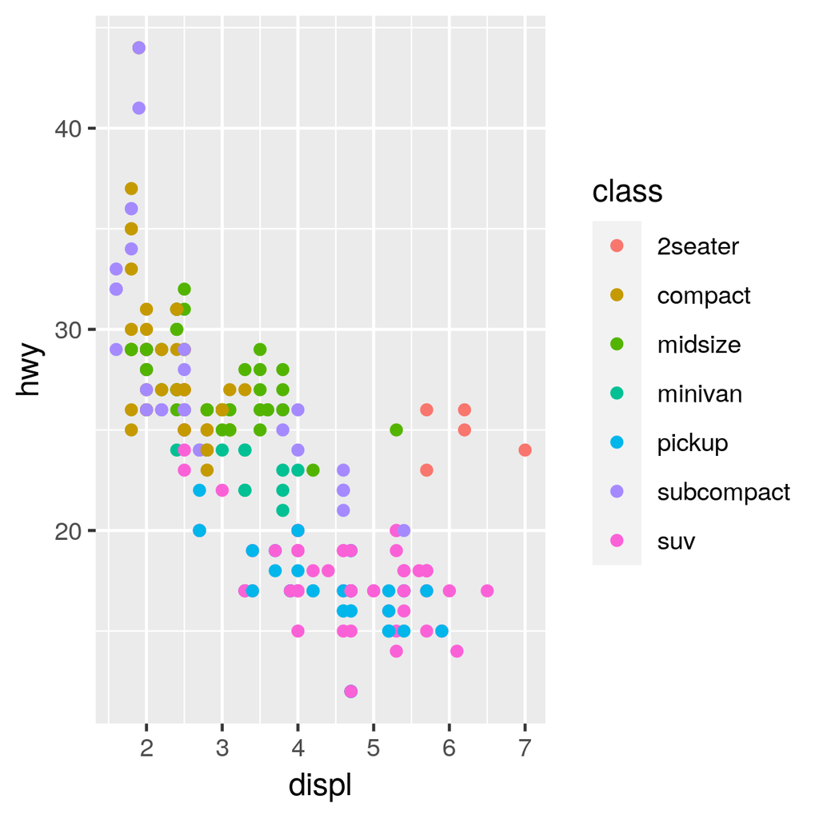

```r
df=mpg
p=ggplot(df,aes(x=displ, y=hwy, color=class))+geom_point()
p
```

`-` 범례지우는방법1

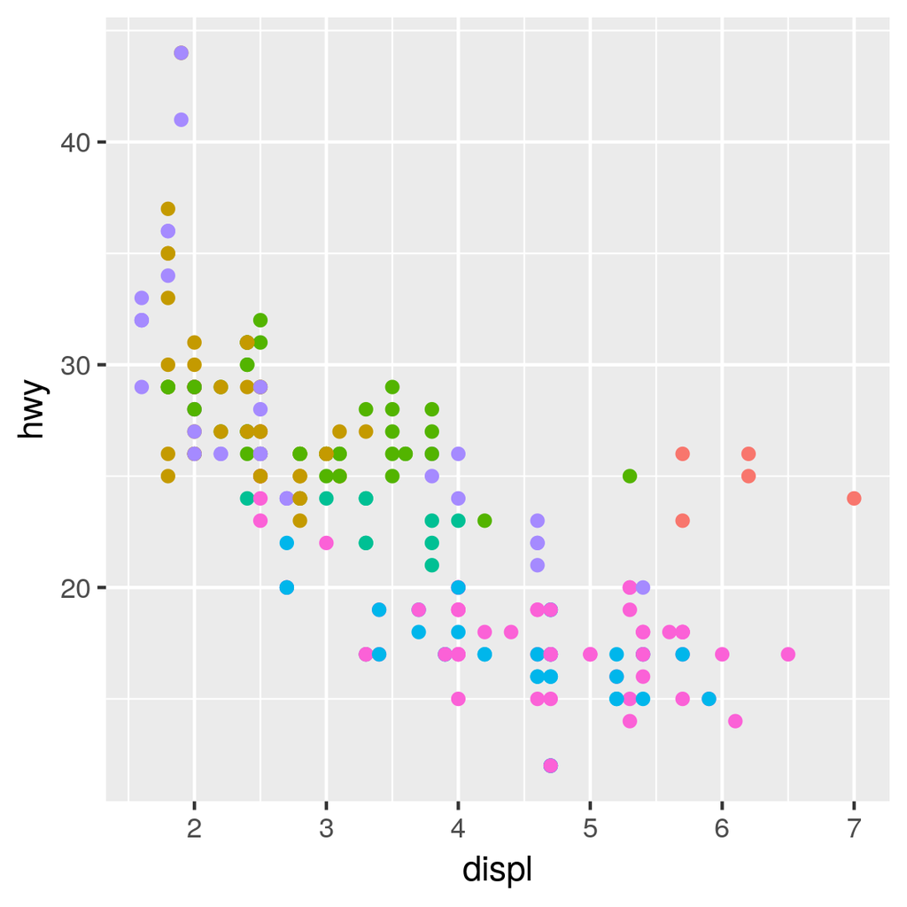

```r
p+guides(color=F) ## 범례지우는 방법 1
```

`-` 범례지우는방법2

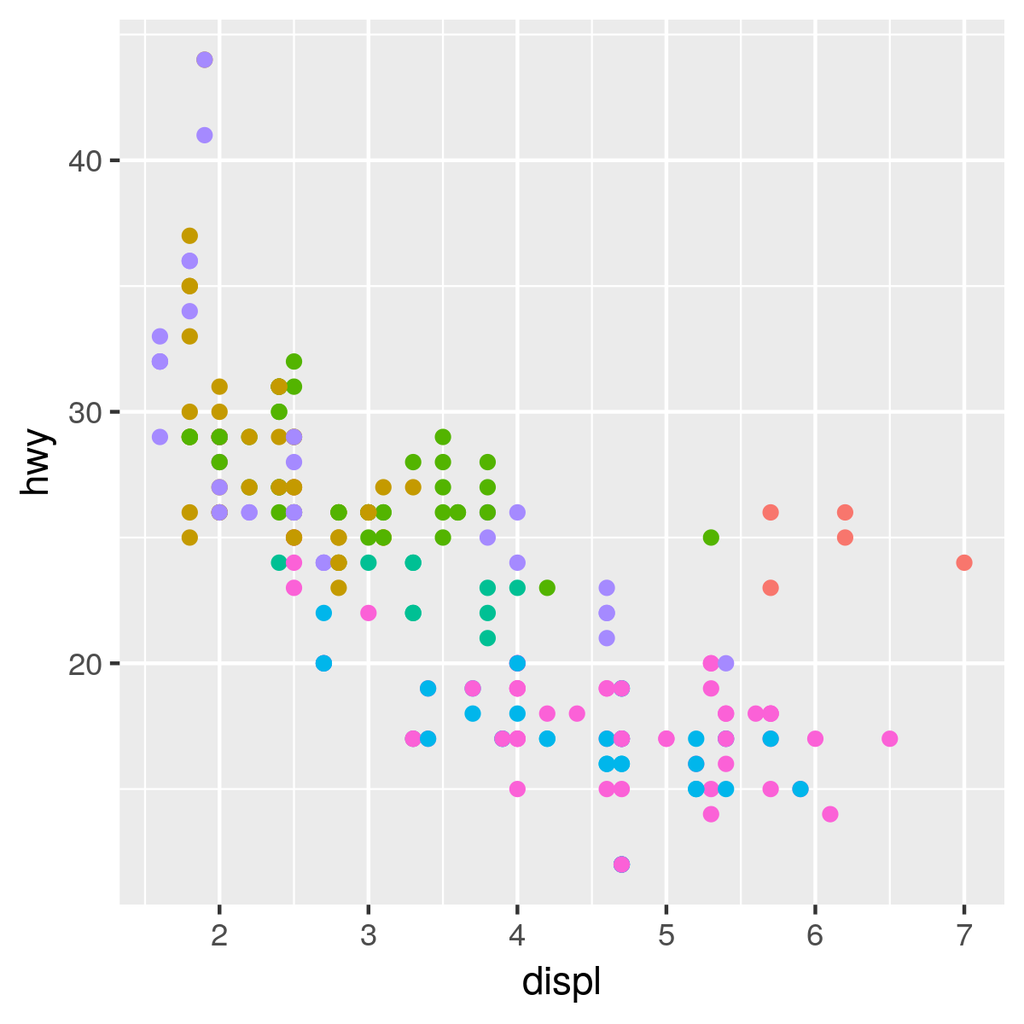

```r
p+theme(legend.position = 'none')
```

### 범례의 크기조정

`-` 예제그림

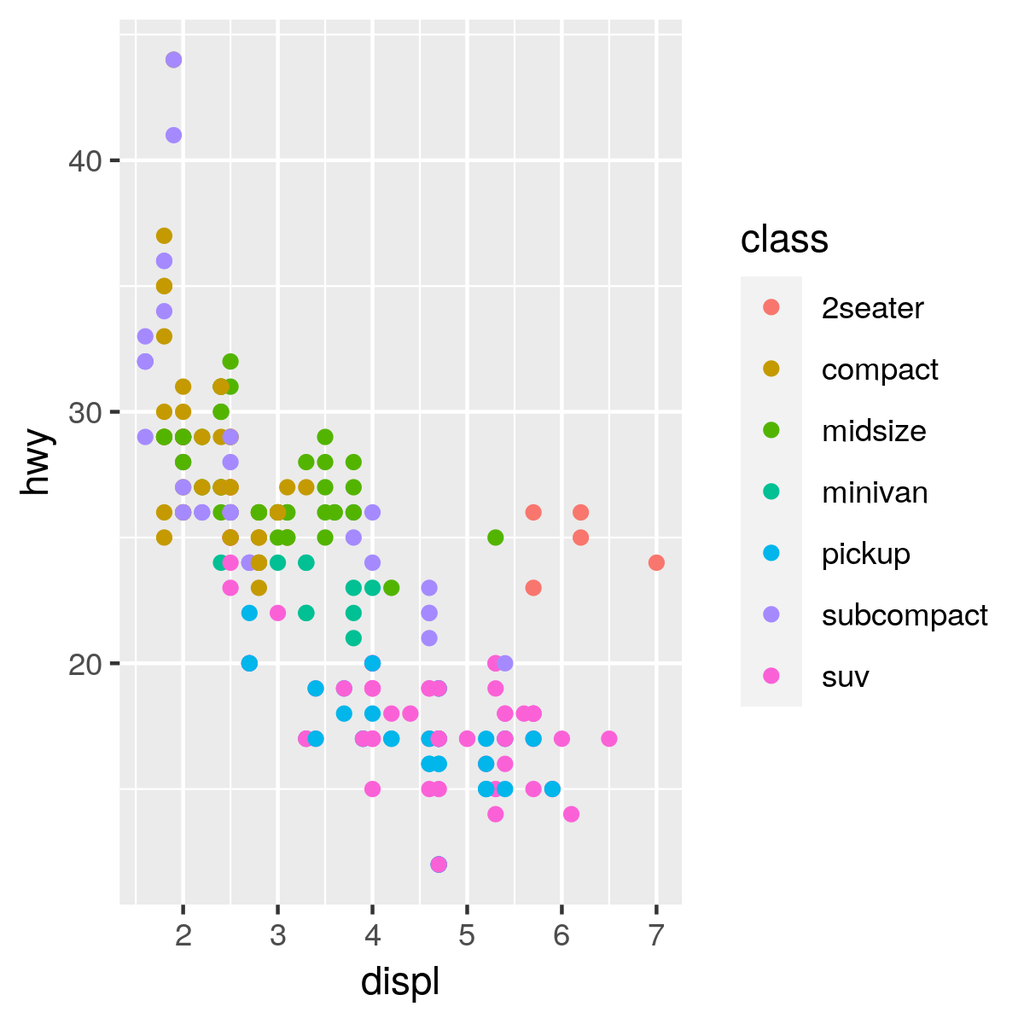

```r
df=mpg
p=ggplot(df,aes(x=displ, y=hwy, color=class))+geom_point()
p
```

`-` 범례의 크기를 조정하는 방법은 아래와 같다.

```
...+theme(legend.key.width = unit(2,"mm"))
...+theme(legend.key.width = unit(4,"mm"))
```

이런식으로 하면 범례가 홀쭉해지기도 하고 뚱뚱해지기도 한다. HST에서 예제2번 칼라바를 홀쭉하게 만들때 사용하였다.

### 범례제목내용변경

`-` 아래와 같이 하면 내용을 변경할 수 있다.

```
...+labs(fill="Condition")
```

여기에서는 예제로 범례가 생성된 에스테틱이 fill이라고 가정하였다. 실제사용할때는 범례가 생성된 에스테틱에 맞춰서 사용하면 된다. 또는 아래와 같은 코드도 동일한 효과를 준다.

```
...+scale_fill_discrete(name="Condition")
```

하지만 labs를 쓰면 아래와 같이 2개이상의 범례도 바꿀 수 있다.

```
...+labs(fill="Condition",colour="Male/Female")
```

### 범례제목스타일변경

`-` 범례의 제목의 글씨체를 변경하고 싶다면 아래와 같이 하라.

```
### r
...+theme(legend.title=element_text(face='italic',size=14))
```

### legend

#### 범례제거

`-` 아래와 같이 guides()를 사용하고 범례를 없애고 싶은 에스테딕을 지정해준다.

```
...+guides(alpha=FALSE)
```

`-` 만약에 모든 에스테틱에 대한 범례를 없애고 싶을때는 아래와 같이 테마시스템을 활용한다.

```
...+theme(legend.position="none")
```

#### 범례크기조정

`-` 범례의 크기를 조정하는 방법은 아래와 같다.

```
...+theme(legend.key.width = unit(2,"mm"))
...+theme(legend.key.width = unit(4,"mm"))
```

이런식으로 하면 범례가 홀쭉해지기도 하고 뚱뚱해지기도 한다. HST에서 예제2번 칼라바를 홀쭉하게 만들때 사용하였다.

#### 범례제목스타일변경

`-` 범례의 제목의 글씨체를 변경하고 싶다면 아래와 같이 하라.

```
### r
...+theme(legend.title=element_text(face='italic',size=14))
```

#### 범례제목삭제

`-` 그냥 범례제목의 글꼴을 변경하는것 보다 범례제목 자체를 삭제하는게 나을수도 있다.

```
...+guides(fill=guide_legend(title=NULL))
```

#### 범례에속한라벨변경

`-` scale함수군을 활용하여 범례를 컨트롤하면 범례에 속한 라벨을 하나하나 바꿀수 있다는 장점이 있다.

```
...+scale_colour_discrete(labels=c("M","F"))
...+scale_colour_discrete(labels=c("Male","Female"))
```

`-` 두개의 에스테틱을 동시에 적용하여 변수를 표현한 경우는 라벨도 동시에 바꿔줘야 한다. 예를들어 남자/여자를 구분하는데 칼라와 shape 에스테틱을 동시에 사용했다면 아래와 같이 한다.

```
...+scale_shape_discrete(labels=c("Male","Female"))+
    scale_colour_discrete(labels=c("Male","Female"))
```

당연한소리 같지만 이런식으로 안하면 shape, colour에 대한 두개의 라벨링이 따로 생긴다. 윈스턴 챙의 교재 p.228을 참고할것.

### axis

#### 축 눈금제거

`-` 축에서 y축의 숫자를 제거하고싶다면 아래와 같이 한다.

```
...+theme(axis.text.y=element_blank())
...+theme(axis.text.x=element_blank())
```

### subplot layout

#### grid.arrange

`-` grid.arrange를 사용하면 subplot을 적절히 배열할 수 있다.

```
grid.arrange(p1,p2,p3,p4,ncol=2,nrow=2)
```

다만 이런식으로 하면 모든 서브플랏들이 동일한 공간을 차지하게 된다. 여기에서 widths와 heights옵션을 사용하면 subplot들의 공간을 적절하게 배열할 수 있다.

```
p12 <- grid.arrange(p1,p2,ncol=2,widths=c(1,2))
p123 <- grid.arrange(p12,p3,nrow=2,heights=c(2,1))
p1234 <- grid.arrange(p123,p4,ncol=2,widths=c(1,2))
```

이 기능이 거의 사기적이므로 잘 이용하자.

### facet

#### axis-limit공유해제

`-` facet의 axis-limit을 공유하고 싶지 않다면 아래와 같이 하면 된다.

```
...+facet_grid(variable~mode, scales = "free")
```

#### facet-title의 스타일변경

`-` facet의 글씨모양을 변경하고 싶다면 아래와 같이 한다.

```
...+theme(strip.text.x = element_text(size = 25, color = "black", face = "bold.italic"))
...+theme(strip.text.y = element_text(size = 20, color = "black", face = "bold.italic"))
```

### ggtitle

#### 제목을 2줄로

`-` 제목을 2줄로 하고싶으면 \n을 활용한다.

```
...+ggtitle("line1\nline2")
```

#### 제목스타일변경

`-` 가장 많이 조정하는것은 아래처럼 글씨체를 바꾸는 것이다.

```
...+theme(plot.title=element_text(face="bold.italic"))
```

그외에 제목의 외형을 변경하고 싶다면 아래를 참고하자.

```
...+theme(plot.title=element_text(
    size=rel(1.5),
    lineheight=0.9,
    family="Times", # Helvetica, Times, Courier.
    face="bold.italic", # plain, bold, italic, bold.italic.
    colour="red",
    hjust=0, #0:left, 0.5=center, 1=right.
    vjust=0, #0:bottom, 0.5=center, 1=top.
    angle=0
    ))
```

어지간한 옵션은 다 이해될것인데 lineheight는 뭔지 잘 모를것이다. 이것은 제목이 2줄일경우 줄간격을 설정하게 해주는 옵션이다.

### scale

#### gradien

`-` 스케일에 그라디언트를 넣고 싶으면 아래와 같이 하라.

```
...+scale_fill_gradient(low="red",high="blue")
```

이것은 빨강에서 시작해서 파랑으로 변하는 그라디언트를 만들어 준다.

```
...+scale_fill_gradient2(low="red",high="blue",mid="white",midpoint=25)
```

이것은 빨강에서 시작해서 하양을거쳐 파랑으로 끝나는 그라디언트를 만들어 준다. 하양지점에 해당하는 값은 25이다.

### ggsave

#### transparent

`-` 그림을 투명하게 저장하고 싶다면 우선 ggpubr 패키지를 로드한뒤에 아래와 같이 하라.

```
library(ggpubr)
p<-p+theme_transparent()
ggsave(plot=p,"p.png")
```

그런데 이렇게하면 배경이 다 날아간다. (좀더 탐구해봐야할듯) 동일한 코드를 파이썬으로 짜고싶다면 아래와 같이 하면 된다.

```
### python
p.savefig('temp.png', transparent=True)
```

여기에서 p는 그림 객체임.